[figure not shown]

# Introduktion

Dalarna står inför stora samhällsutmaningar som i många stycken delas med övriga Sverige, Europa och världen. I juni 2021 antog Regionfullmäktige i Dalarna en ny regional utvecklingsstrategi: Dalastrategin - Tillsammans för ett hållbart Dalarna. Strategin är ett stöd och en språngbräda i arbetet med att rusta Dalarna för att möta framtidsutmaningarna och göra dem till möjligheter. Dalastrategin är indelad i tre olika målområden som kopplar an till de olika dimensionerna av hållbarhet - miljömässig, ekonomisk och social hållbarhet: ett klimatsmart Dalarna, ett konkurrenskraftigt Dalarna och ett sammanhållet Dalarna.

En princip för genomförandet av Dalastrategin är ett kunskapsbaserat arbetssätt, vilken bland annat innefattar uppföljning, utvärdering och ett kontinuerligt lärande. En central del av uppföljningsarbetet är de indikatorer som kopplas till respektive målområde och den här rapporten är en del av den årliga uppföljningen av utvecklingen i länet baserat på dessa indikatorer.

| Klimatsmart | Konkurrenskraftigt | Sammanhållet |
| --- | --- | --- |
| Utsläpp av klimatpåverkande växthusgaser | Representation i chefspositioner | Trångboddhet |
| Energiproduktion | Ginikoefficient | Boendetyper |
| Energieffektivitet | Internationaliseringsgrad | Tillgång till service och tjänster |
| Insamlat hushållsavfall (kg/person) | Branschbredd och branschstruktur* | Tillgänglighet till vård* |
| Avfall/BRP | Nyföretagande | Deltagande i det civila samhället |
| Laddinfrastruktur för fordon* | Andel av transporter via olika trafikslag* | Andel av hushåll som har tillgång till bredband |
| Andel kollektivt resande | Tillgänglighet (restid) till arbetsplatser/skolor* | Valdeltagande |
| Självförsörjningsgrad av energi och livsmedel | Infrastrukturinvesteringar | Tillit till andra människor |
| Andel hektar formellt skyddad produktiv skogsmark | Matchningsgrad | Digitalt deltagande* |
| Arealen betesmark och areal med särskilt höga biologiska värden* | Andel sysselsatta | Andel invånare i ekonomiskt utsatta hushåll |
|  | Långtidsarbetslöshet | Andel unga som upplever att de är delaktiga i sin kommun |
|  | Andel unga som inom fyra år fullföljer gymnasieutbildning | Självskattad hälsa |
|  | Andel högskoleutbildade i befolkningen |  |
|  | Etableringstid för nyanlända |  |
|  | Investeringar i FoU |  |

*Datainsamling pågår och indikatorn är under utveckling

# Ett klimatsmart Dalarna

Ett klimatsmart Dalarna är ett resurseffektivt Dalarna utan klimatpåverkande utsläpp. Resande sker på ett enkelt och miljömässigt hållbart sätt. I ett klimatsmart Dalarna är samhällets robusthet och resiliens vid klimatförändringar god.

Den miljömässiga dimensionen i regional utveckling handlar om att säkerställa att ekosystemen fortsätter leverera de tjänster som samhället är beroende av. Genom att gå före i en miljömässigt hållbar omställning gynnas innovationer och regionalt företagande när regionala lösningar bidrar till att lösa globala problem. Det är också så vi skapar goda livsmiljöer och levnadsvillkor.

## Utsläpp av klimatpåverkande växthusgaser

2017 antogs ett långsiktigt nationellt mål om att Sverige ska vara klimatneutralt år 2045. Detta är definierat som minst 85 procent lägre växthusgasutsläpp inom landets gränser jämfört med år 1990. Målet innebär i princip att alla sektorer och verksamheter behöver vara fossilfria år 2045. De nationella målen bidrar till det internationella Parisavtalet samt det europeiska målet om 85-90 procent minskning av utsläppen till år 2050.

Utsläppen i Dalarna visar på en positiv trend där utsläppen av växthusgaser har minskat över tid. Även om detta är en utveckling i rätt riktning kommer det att krävas en ännu snabbare minskningstakt för att kunna uppnå målen på både nationell nivå och för att svara upp mot ambitionerna i Dalastrategin. I ett nationellt perspektiv ligger Dalarna högre än riksgenomsnittet sett till utsläpp per person, trots en minskning från knappt 7,5 till drygt 5,5 ton/invånare. Likt övriga Sverige är det industrin och transporterna i länet som står för den största andelen utsläpp av växthusgaser.

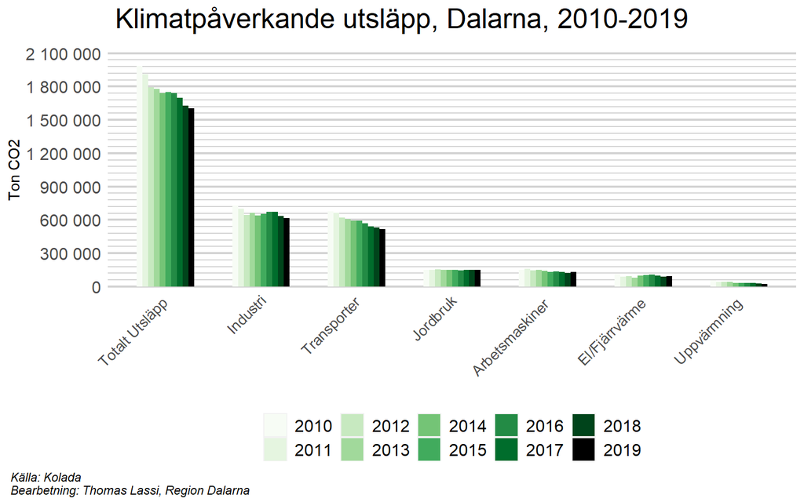

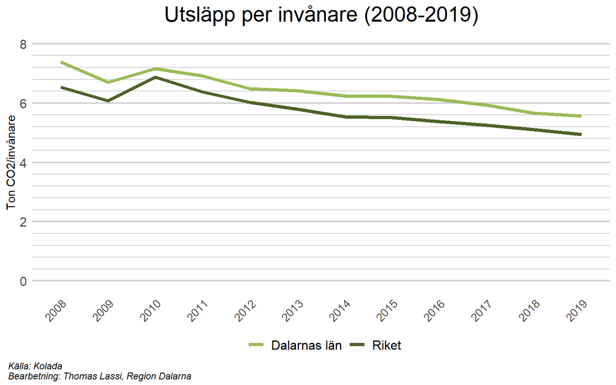

## Energiproduktion

I Dalastrategin konstateras det att en god tillgång till hållbar energi är avgörande för näringslivets och hela samhällets omställningskapacitet. En ökad produktion av förnybar energi bidrar till såväl minskade utsläpp som ökad självförsörjning och resiliens för Dalarna.

Elproduktionen i Dalarna består nästan uteslutande av vindkraft och vattenkraft. Även om produktionen av el från vattenkraft varierar mellan olika år, delvis beroende på om det är torrår eller våtår, så står vattenkraften för den största andelen av elproduktionen i länet. Betydelsen av vindkraft för elproduktionen i länet har ökat över tid och 2020 hade elproduktionen från vindkraft mer än fördubblats jämfört med 2012.

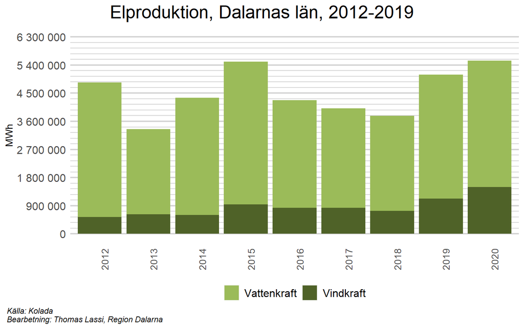

## Energieffektivitet

Utsläpp av koldioxidekvivalenter, som redovisas under en annan indikatorrubrik, är ett centralt mått för att följa upp Dalarnas ambitioner om reducerade utsläpp av växthusgaser. En annan relaterad indikator i Dalastrategin berör energieffektiviteten i länet. Dalarnas energieffektivet kan mätas som förädlingsvärde per ton koldioxidekvivalenter och kopplar därmed utsläppen i länet till den ekonomiska aktiviteten. Förändringen av energieffektiviteten kan användas för att visa på framsteg inom en region, där en positiv utveckling vore ett högre BRP-värde per utsläppt ton koldioxid.

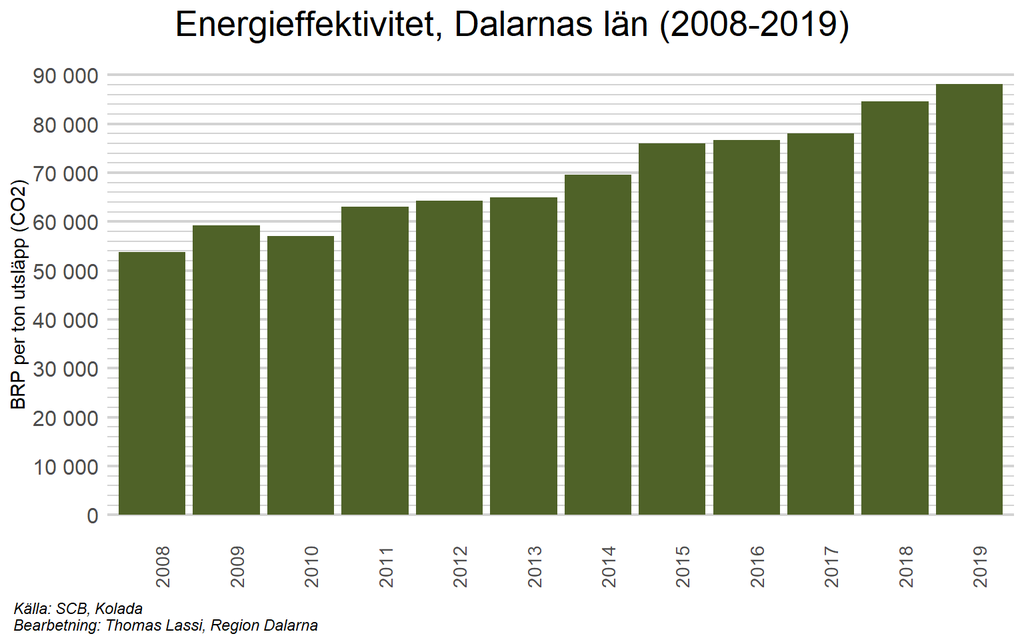

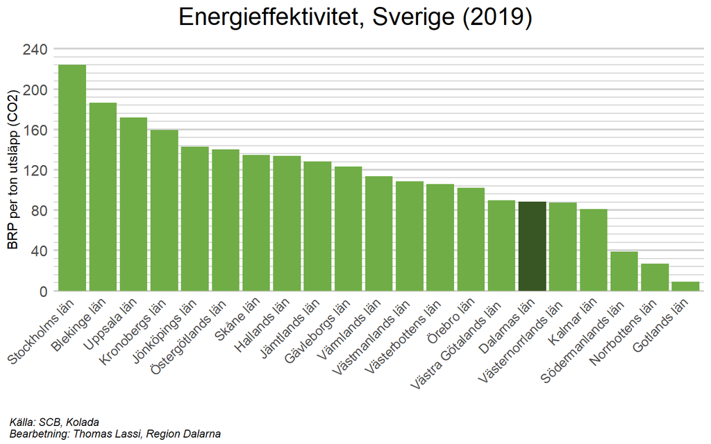

## Insamlat hushållsavfall (kg/person)

Dalastrategin belyser att en miljömässigt hållbar omställning är en grundläggande utmaning som berör alla delar av samhället, från global till lokal nivå och inom alla sektorer. En av prioriteringarna i Dalastrategin är att främja cirkulär ekonomi och resurseffektivitet i länet. Ett mått på hur effektivt resurser i länet används är mängden insamlat kommunalt avfall. I sammanställningen nedan visas insamlat kommunalt avfall per person och år i Dalarna från 2013 till 2020. 2013 samlade Dalarnas län in 497kg avfall per person, att jämföra med 505 kg/person år 2020. Som jämförelse har Region Stockholm minskat sitt insamlade avfall från 480 kg/person till 409 kg/person under samma period.

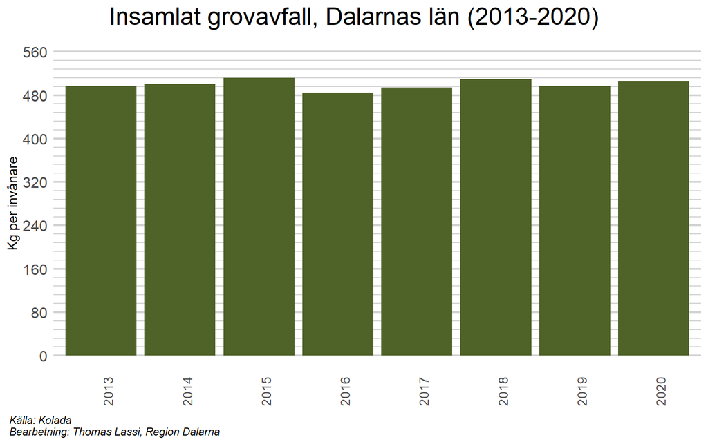

## Avfall/BRP

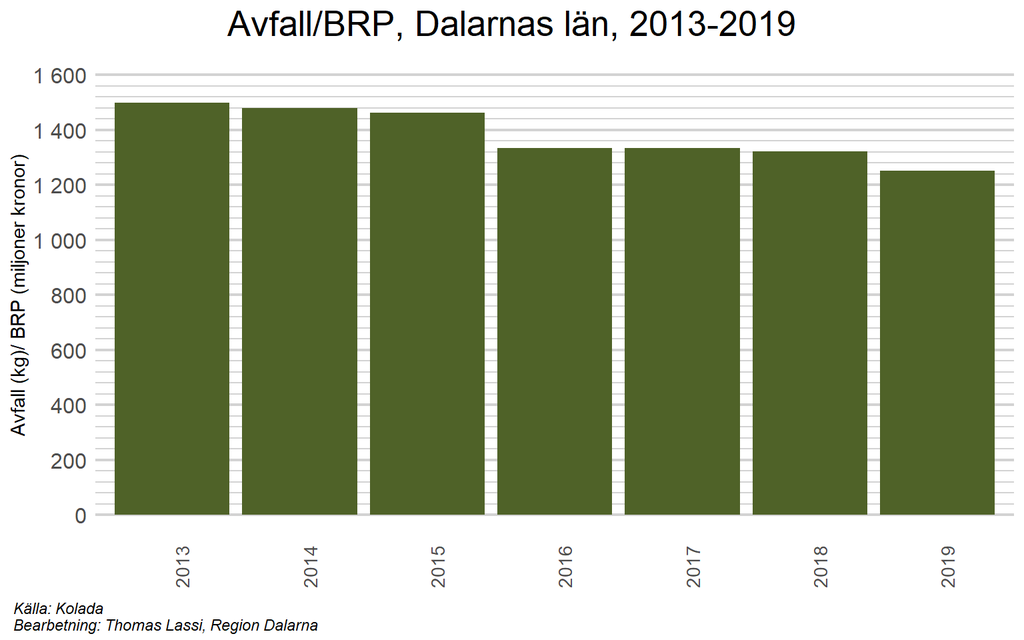

## Andel kollektivt resande

På grund av sin utsträckta geografi har Dalarna en utmaning i att utveckla transportinfrastrukturen ur ett hållbarhetsperspektiv. För att nå klimat- och energimålen krävs kraftfull teknisk utveckling i kombination med beteendeförändringar. Kollektivt resande har en central roll i utvecklandet av en klimatsmart och resurseffektiv, men också mer jämställd och jämlik mobilitet. Den traditionella kollektivtrafiken måste kompletteras med nya mobilitetslösningar och tjänster, särskilt för länets glesa miljöer. Kollektivtrafik är förenat med höga kostnader, samtidigt som det finns samhällsekonomiska vinster. För att klara omställningen krävs mod att ställa olika kostnader mot varandra. Det kollektiva resandet behöver öka.

Här redovisas två olika diagram som indikatorer för kollektivt resande i Dalarna: resor per invånare samt marknadsandel för kollektivtrafik i länet. För resor/invånare syns att det kollektiva resandet har legat på en stabil nivå kring 35 resor per person från 2013 fram till utbrottet av Covid-19 i Sverige och Dalarna. I det som förmodligen är en konsekvens av pandemin syns en nedgång i det kollektiva resandet under 2020. Marknadsandelen för kollektivtrafik beräknas som andelen resor med kollektivtrafik (linjelagd buss, spårvagn, tunnelbana, pendeltåg, tåg och båt) och taxi av det totala antalet resor med Kollektivtrafik, taxi, bil (förare och passagerare) samt moped/MC. Även här bryts uppgången i en förmodad pandemieffekt efter ett antal år av ökande marknadsandel för kollektivtrafiken.

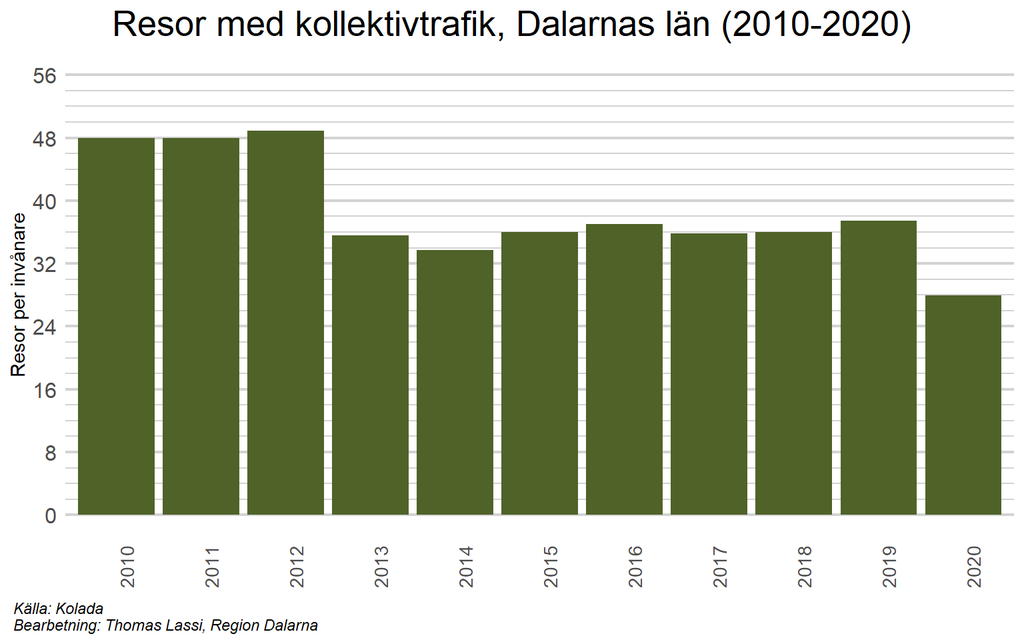

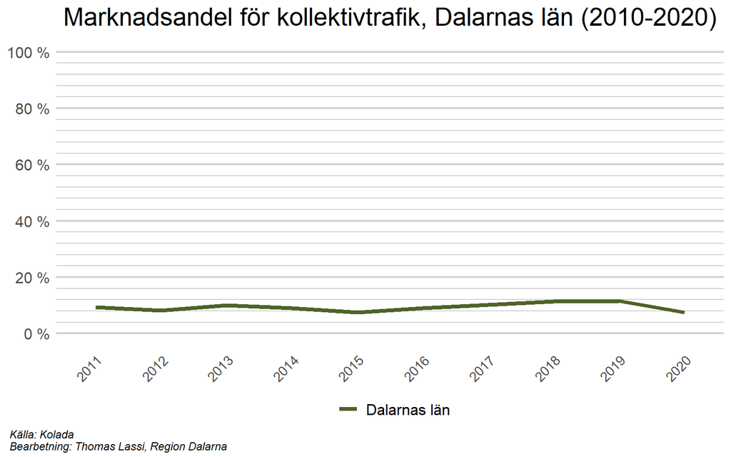

## Självförsörjningsgrad av energi och livsmedel

För att klara utmaningarna med ett förändrat klimat behöver samhället planera för olika belastningar i form av nederbörd, torka, vind, insekts- och svampangrepp på grödor och skog, höga temperaturer med mera. Här spelar god samhällsplanering på regional och kommunal nivå en viktig roll. Samhällets beredskap behöver utvecklas för att möta de olika typer av risker som nu ökar till följd av förändringar i klimatet. En lokal och hållbar livsmedelsproduktion i Dalarna är viktig för såväl ökad självförsörjningsgrad som för biologisk mångfald. En lokal och hållbar livsmedelsproduktion i Dalarna är viktig för såväl ökad självförsörjningsgrad som för biologisk mångfald.

Det första diagrammet visar ett teoretiskt mått på självförsörjning av livsmedel i länet där producerat livsmedel inom fem kategorier (fårkött, griskött, matpotatis, mjölkprodukter samt nötkött) visas som en andel av det som har konsumerats inom samma kategorier i länet. Diagrammet visar tydligt att befolkningen i Dalarna konsumerar mer inom samtliga dessa kategorier jämfört med det som produceras i länet.

Det andra diagrammet visar ett teroretiskt mått på självförsöjning av energi i Dalarna där den totala elproduktionen i länet visas som en andel av den total elförbrukningen. Diagrammet visar en positiv trend för självförsörjningsgraden av energi, en trend som drivs både av en ökande produktion samt en minskande konsumtion.

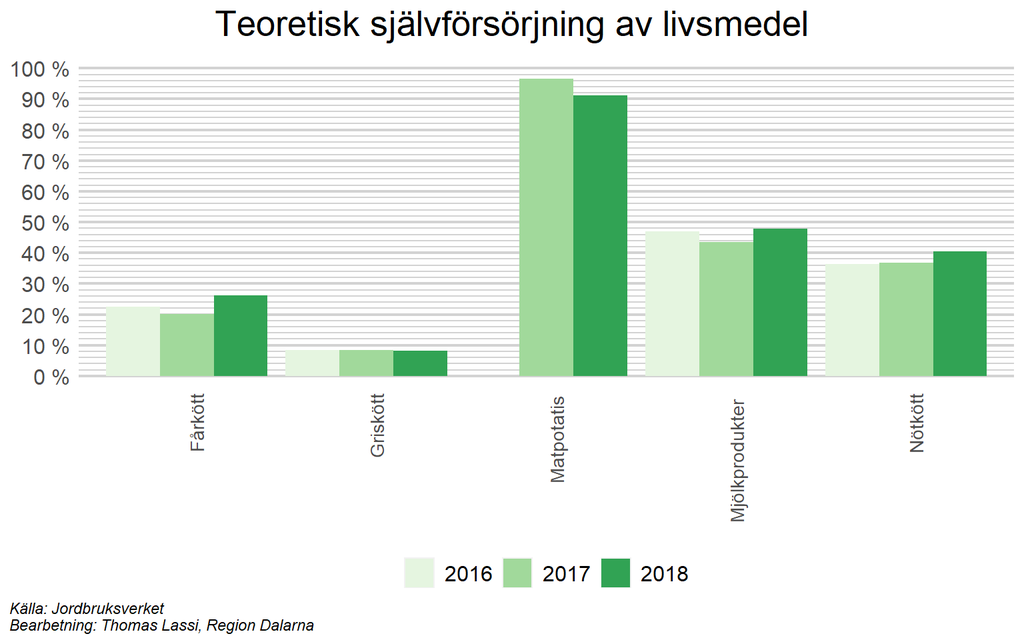

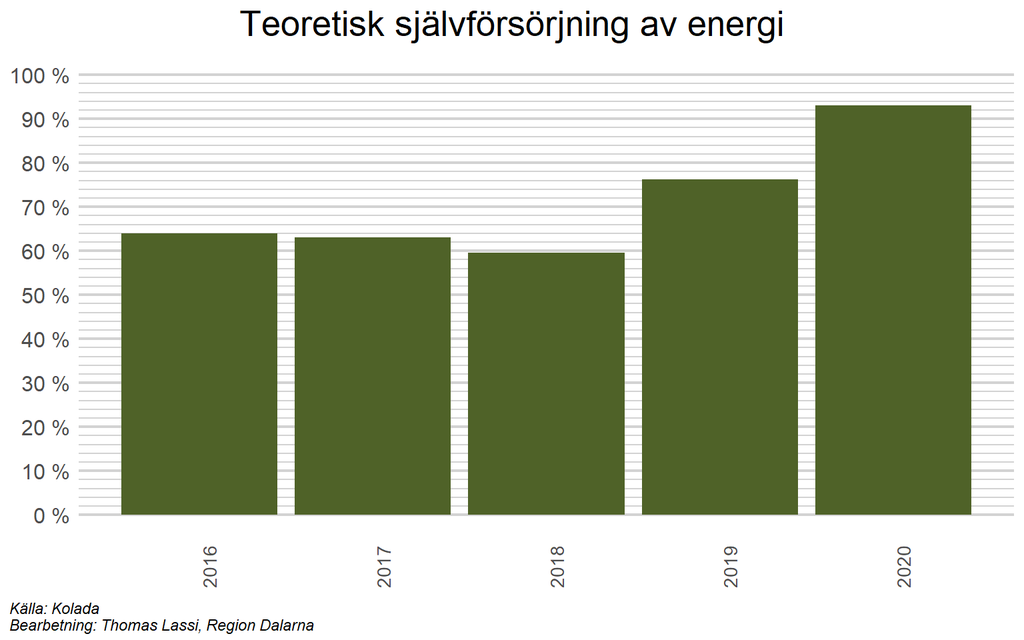

## Andel hektar formellt skyddad produktiv skogsmark

Regeringen har fattat beslut om Sveriges första nationella skogsprogram och i Dalastrategin omnämns skogsbruket som en av länets viktiga näringar. Skogen påverkas också av klimatförändringarna och skötsel och brukande behöver anpassas därefter. I diagrammen nedan redovisas utvecklingen för skyddad produktiv skogsmark i Dalarnas län mellan 2018 och 2020. Arealen skyddad skogsmark i länet har minskat något från 116500 hektar till 115400 hektar. Procentuellt var 6.1 procent av den produktiva skogsmarken i Dalarnas län skyddad 2018 och samma siffra för 2020 var 5.9 procent.

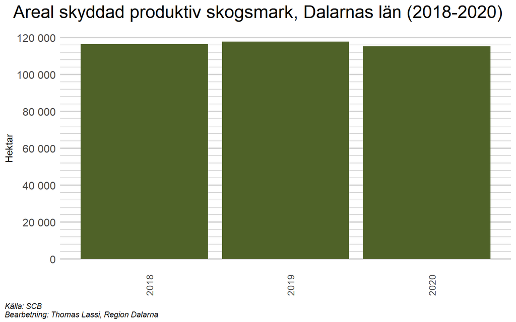

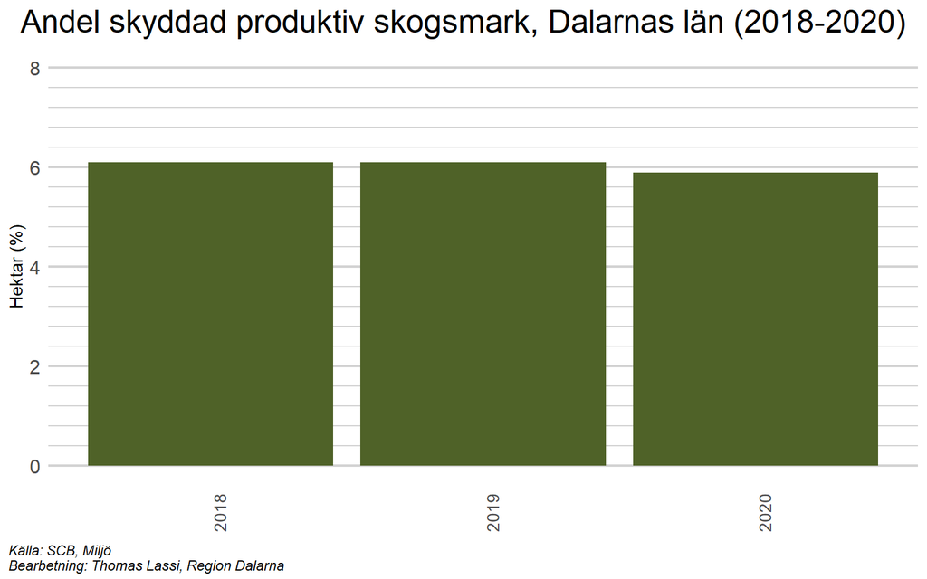

## Arealen betesmark och areal med särskilt höga biologiska värden

Biologisk mångfald och väl fungerande ekosystem är en förutsättning för allt liv på jorden. Det är också en bas för goda livsmiljöer både för Dalarnas invånare och för Dalarnas näringsliv. Ekosystemen behöver förvaltas så att de fortsatt kan bidra med många olika funktioner samtidigt. Samhället vinner på aktiva och hållbara näringar och mångfunktionella landskap där natur- och kulturvärden tillvaratas. Grön infrastruktur är ekologiskt funktionella nätverk av livsmiljöer och naturområden som utformas, brukas och förvaltas så att den biologiska mångfalden bevaras och därmed främjar de för samhället så viktiga ekosystemtjänsterna.

I diagrammet nedan redovisas utvecklingen för arealen betesmark i Dalarnas län mellan 2011 och 2020. Arealen har under denna period minskat från 11908 till 10526 hektar. Denna negativa trend går också emot den nationella trenden, där arealen betesmark har ökat något i riket som helhet.

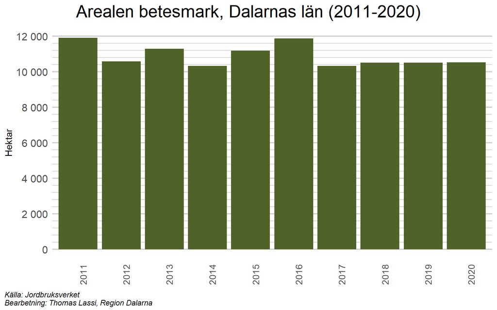

# Ett konkurrenskraftigt Dalarna

I ett konkurrenskraftigt Dalarna är näringslivet livskraftigt och bidrar till hållbar tillväxt. En väl utvecklad och hållbar infrastruktur skapar värden för näringsliv, boende och besökare. Det är ett Dalarna där allas kunskaper och kompetenser tas tillvara och där individer, näringsliv, offentlig sektor och civilsamhälle utvecklas tillsammans, i samspel med omvärlden. Det är också ett nyskapande Dalarna där utmaningsdriven innovation bidrar till ett gott samhälle och hållbar tillväxt.

Den ekonomiska dimensionen av hållbarhet i det regionala utvecklingsarbetet handlar om att skapa konkurrenskraft och sysselsättning vilket uppnås genom att använda, hushålla med och förädla idéer och resurser, på ett miljömässigt och socialt hållbart sätt. Med ett cirkulärt system där resurser och värden ständigt återskapas främjas en ekonomiskt hållbar utveckling.

## Representation i chefspositioner

Kvinnors och mäns jämställda medverkan och inflytande i näringslivet, på arbetsmarknaden och i innovationsarbete är och blir en alltmer kritisk tillväxtfaktor. Konkurrenskraften stärks om kompetenser från olika grupper oavsett ålder, kön eller bakgrund tas tillvara. En viktig indikator inom detta område är representation på arbetsmkarnaden, speciellt i chefspositioner. För 2019 ser vi att det fanns en överrepresentation av män i chefspositioner på arbetsmarknaden. Kvinnor och utrikes födda var däremot underrepresenterade.

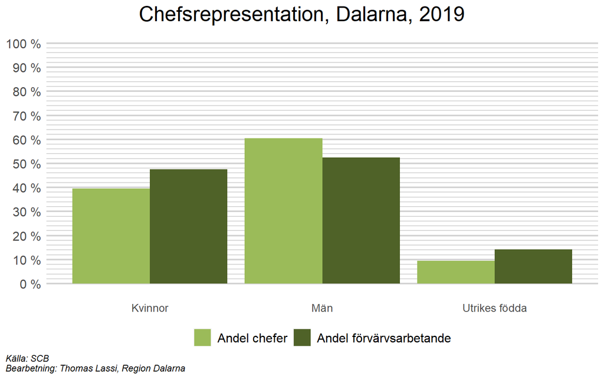

## Ginikoefficient

I Dalastrategin lyfts ekonomiska klyftor som en framtidsutmaning för länet. För att redovisa ojämnheten i inkomstfördelningen används gini-koefficienten. Ett högt värde på koefficienten visar på större ojämnhet. Här redovisas ginikoefficienten avseende disponibel inkomst per konsumtionsenhet. Konsumtionsenhet avser ett viktsystem där konsumtionen är relaterad till hushållets sammansättning. Den disponibla inkomsten divideras med den konsumtionsvikt som gäller för hushållet.

För Dalarnas räkning har ginikoefficienten ökat något från 2011 till 2020, vilket visar på en ökad ekonomisk ojämnhet i länet, med en toppnotering 2019. Ginikoefficienten för länet ligger under koefficienten för riket i samtliga år förutom 2019. 2019 avviker dock så skarpt från den generella trenden för ginikoefficienten att det årets notering ska betraktas med försiktighet. Ökningen från 2011 och framåt är dock tydlig även om man bortser från 2019.

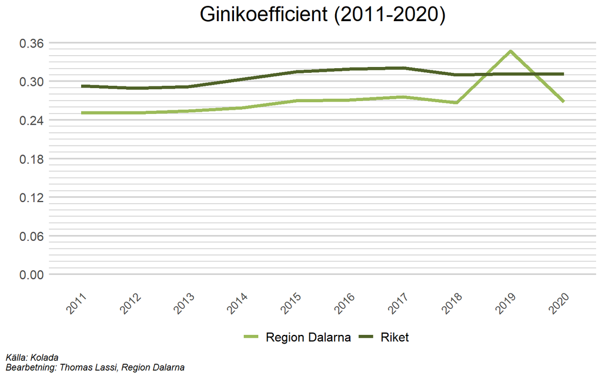

## Internationaliseringsgrad

Dalarna är beroende av omvärlden. Internationell samverkan behövs både för att möta samhällsutmaningar och för att ta vara på möjligheter till import, investeringar och export av våra företags varor och tjänster. I länet finns världsledande företag i olika storlek som deltar i globala värdekedjor, en del av de mindre utsätts för global konkurrens trots att de bara eller främst levererar till sin regionala storkund.

En indikator som används för att följa utvecklingen inom detta område är internationalisering. Internationalisering är ett komplext koncept och kan bestå av flera olika delar (exempelvis handel, arbetsmarknad och turism). För uppföljningen av denna indikator används Tillväxtverkets regionala internationaliseringsindex som är ett sätt att illustrera hur internationellt integrerade olika regioner är baserat på ett antal olika variabler. Indexet gör det möjligt att följa hur internationaliseringen utvecklas över tid i olika regioner (län).

För 2020 ligger Dalarna i mittenskiktet av svenska regioner för internationalisering. Den region som presterar bäst är Västra Götalandsregionen och alla andra regioner sätts i relation till den regionen. Dalarna presterar bättre än de andra regionerna som inkluderas i Norra Mellansverige (Gävleborg och Värmland). Resultatet för Dalarna är till viss del ett resultat av att länet presterar bra på delindexet för turism där länet hamnar på en tredje plats bakom Norrbotten och Jämtland.

När det kommer till utveckling över tid har Dalarna däremot presterat sämre än genomsnittet för Sveriges regioner under perioden från 2016-2020.

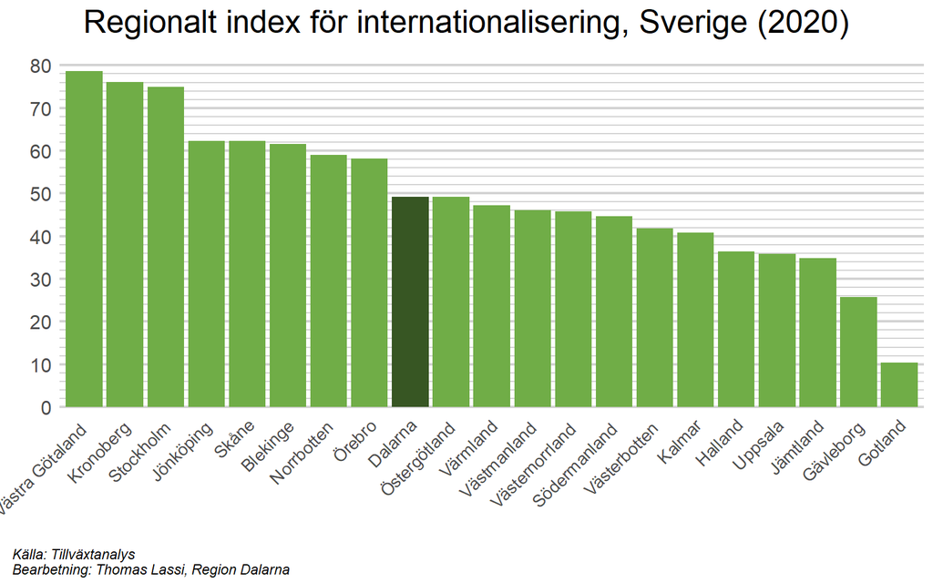

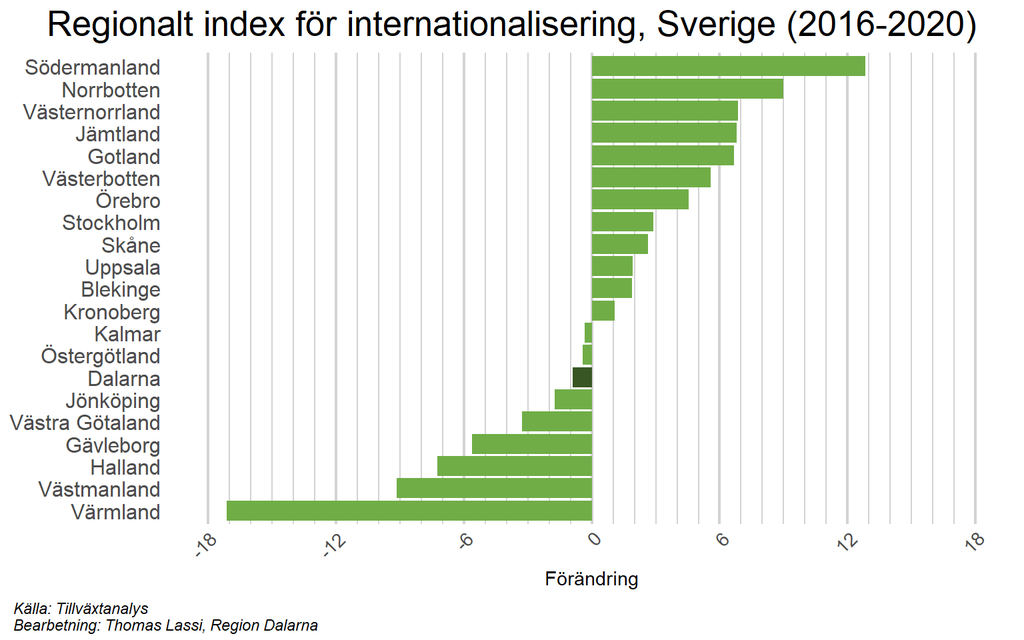

## Nyföretagande

För ekonomins och samhällets förnyelse är entreprenörskap en avgörande faktor. Dalarna behöver fler, och olika typer av entreprenörer och en av prioriteringarna i Dalastrategin är att främja entreprenörskap och företagande. Denna indikator mäter antalet nystartade företag i geografin. Antalet nystartade företag per år i Dalarna har ökat över tid där toppnoteringen nåddes 2020 med 1744 stycken. År 2007 gjordes en större förändring i statistiken över nystartade företag vilket kan förklara den skarpa förändringen från 2006 till 2007.

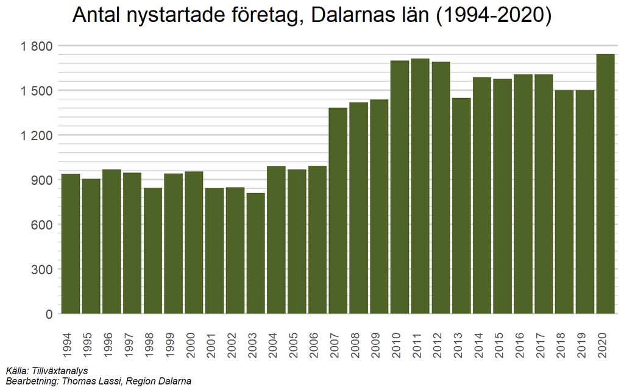

## Matchningsgrad

En förbättrad matchning mellan arbetsmarknadens behov och arbetskraftens kompetens är nödvändig. Bland annat handlar det om att få till en bättre samverkan mellan utbildningsanordnare, branscher, näringsliv, civilsamhället och myndigheter samt över kommun- och länsgränser. Matchningsindikatorn följer upp hur väl Dalarna lyckas med ambitionen om bättre matchning.

Matchningsgrad visar andelen anställda som arbetar i yrken som stämmer väl överens med deras utbildning. För att detta ska gälla ska det dels finnas en stark överensstämmelse mellan utbildningens och yrkets ämnesinriktning (t.ex. teknikutbildning – teknikyrke) och dels ska utbildningsnivån vara rätt i förhållande till vad yrket kräver. Matchningsgraden i Dalarna är något högre för kvinnor än för män. För kvinnor ligger matchningsgraden 2019 på 69,4 procent. För män var motsvarande mått 67,9 procent. Matchningsgraden för båda dessa grupper har sjunkit under perioden 2015-2019 och låg i det sista året under perioden på 68,6 procent.

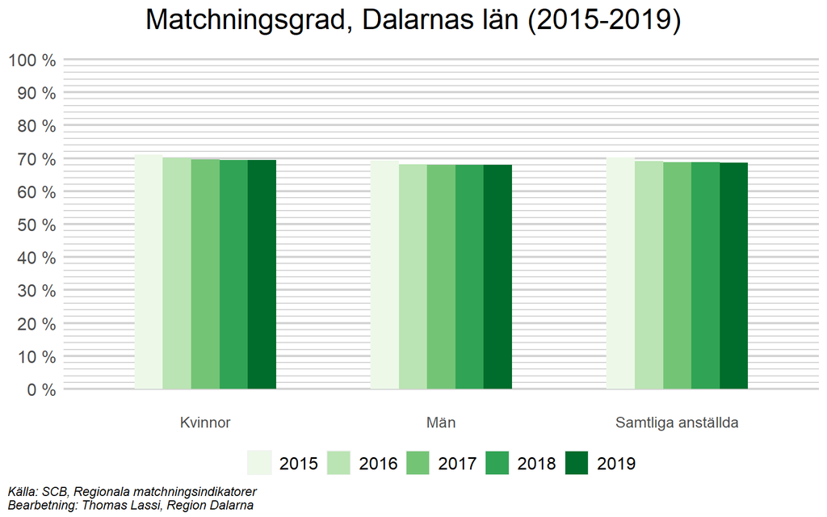

## Andel sysselsatta

Dalastrategin slår fast att sysselsättningsgraden i länet behöver öka och skillnader i denna mellan grupper behöver minska. Detta mäts genom en indikator för förvärvsarbetande i länet uppdelat på kön. I första året för den inkluderade tidsperioden, 2013, räknades 77,1 procent av kvinnorna i länet som förvärvsarbetande. Motsvarande siffra för männen i Dalarna var 79,9 procent. Gapet mellan kvinnor och män var därmed knappt 3 procent. Utvecklingen inom båda grupperna har varit positiv. 2020 var 79,2 procent av kvinnorna förvärvsarbetande och motsvarande siffra för männen i länet var 81 procent. Gapet mellan dessa grupper har därmed krympt till knappt 2 procent (1,8). Totalt sett har andelen förvärvsarbetande i Dalarna ökat från 78,6 till 80,1 procent.

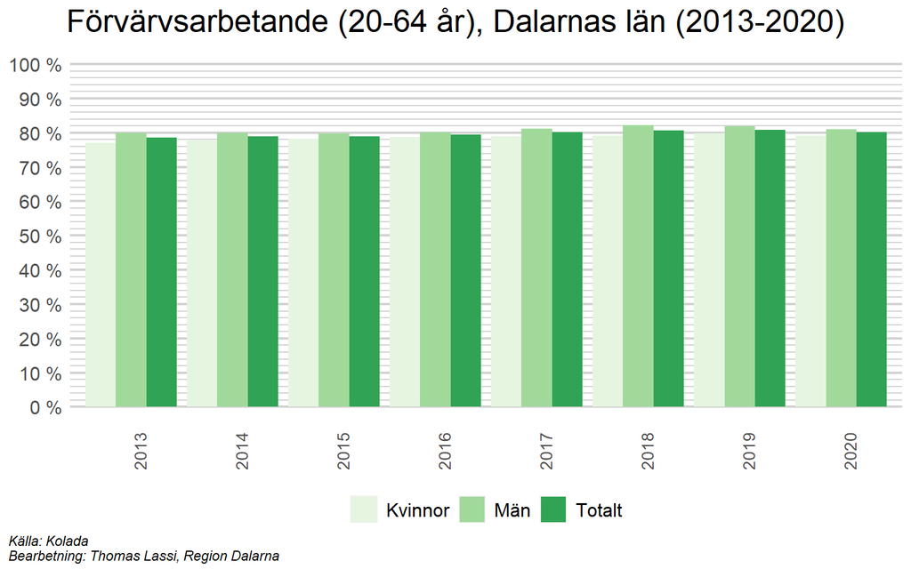

## Långtidsarbetslöshet

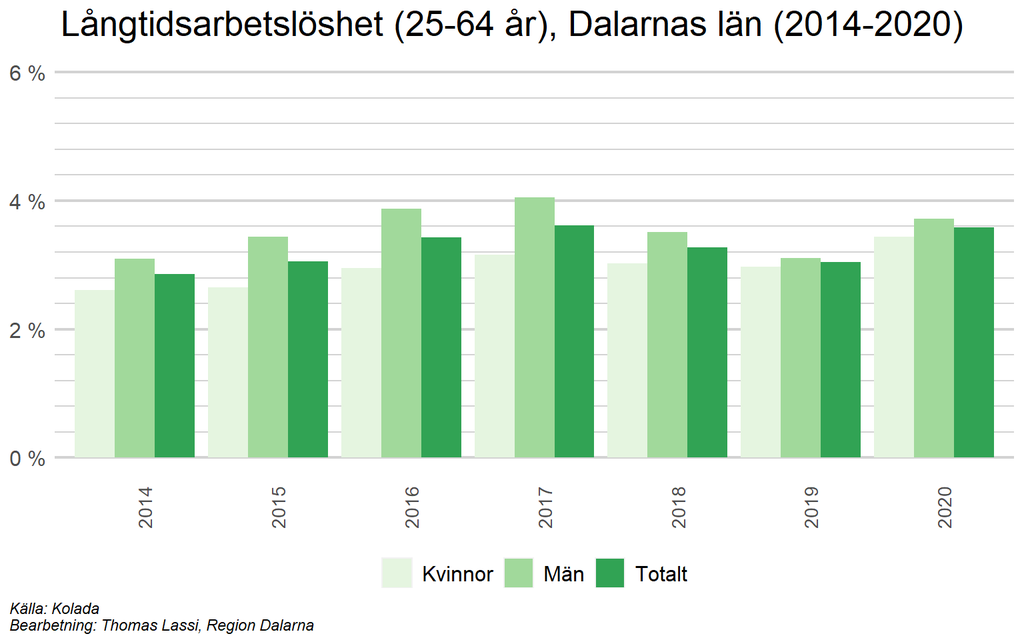

## Andel unga som inom fyra år fullföljer gymnasieutbildning

Kunskap ger människor möjlighet att växa och påverka sin livssituation. Tillgång till bildning, kunskap och kompetens är avgörande för såväl utvecklingen av samhället, god välfärd och tillväxt i näringslivet. När arbetsgivare inte hittar rätt kompetens hämmas den ekonomiska utvecklingen. Samtidigt försvagas den sociala hållbarheten när människor ställs utanför arbetsmarknaden. Låga utbildningsnivåer är en utmaning i stora delar av Dalarna. Ambitionen i Dalastrategin är därmed att fler ska klara en gymnasiexamen för att kunna etablera sig på arbetsmarknaden.

Denna indikator mäter andelen gymnasiestudenter som har fullföljt sin utbildning inom fyra år i Dalarna. Utvecklingen över tid från 2011 till 2017 är negativ. Av studenterna som började läsa på gymnasiet i Dalarna 2011 är det 72,6 procent som inom fyra år fullföljde sin utbildning med examen. Motsvarande mått för 2017 är 69,9 procent och därmed en minskning med 2,7 procent.

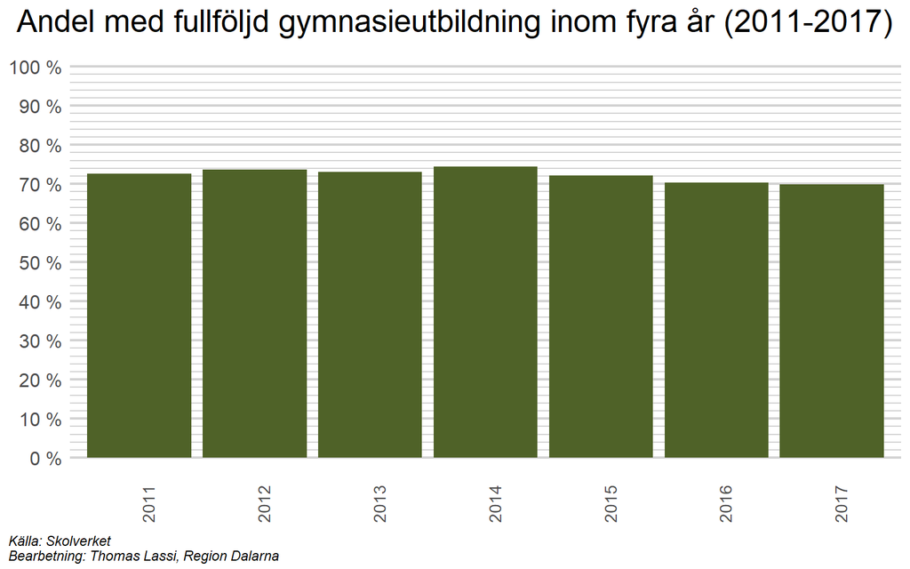

## Andel högskoleutbildade i befolkningen

Med en alltmer kunskapsintensiv ekonomi ökar också behovet av eftergymnasialt utbildade. Dalastrategin lyfter betydelsen av en stark regional högskola med närvaro i hela länet. Även andra utbildningsformer såsom folkhögskolor, yrkesvux och yrkeshögskolor bidrar till stärkt kompetensförsörjning i form av såväl bredd som spets. Indikatorn innefattar invånare med eftergymnasial utbildning mellan 25 och 64 år. Med eftergymnasial utbildning avses eftergymnasial utbildning kortare än 3 år, längre än 3 år samt forskarutbildning.

Indikatorn visar på en positiv utveckling över tid där andelen med eftergymnasial utbildning har ökat från 31,2 procent till 34,2 procent mellan 2013 och 2020. Det finns också en uppenbar skillnad mellan män och kvinnors utbildningsnivå. 2020 hade 41,7 procent av kvinnorna i Dalarna någon form av eftergymnasial utbildning. Motsvarande siffra för männen i Dalarna var avsveärt lägre på 27 procent.

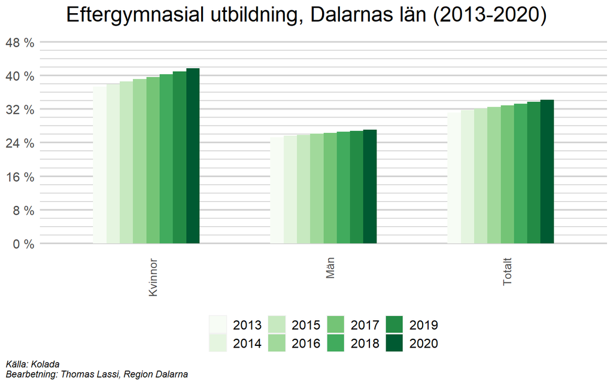

## Etableringstid för nyanlända

Invandringen är en del i lösningen för god kompetensförsörjning. Dalarna har haft en relativt stor inflyttning av utomeuropeiskt födda under senare år. Då många nyanlända är i arbetsför ålder är de ett viktigt tillskott till arbetskraften. Denna indikator är ett mått på i vilken utsträckning nyanlända etablerar sig på arbetsmarknaden i Dalarna.

Andelen etablerade på arbetsmarknaden ökar efter vistelsetid i landet. Bland gruppen nyanlända som har vistats i Sverige en kortare period (exempelvis upp till ett år) är andelen förvärvsarbetande avsevärt lägre jämfört med nyanlända som har vistats i landet en längre tid. För det senaste året i period, 2020, hade knappt 37 procent av nyanlända med vistelsetid under ett år etablerat sig på arbetsmarknaden. Andelen etablerade på arbetsmarknaden stiger sedan alltmer efter vistelsetid och för samma år var det lite drygt 71 procent i gruppen som vistats i Sverige i tio år eller mer som etablerat sig.

Ytterliggare en trend är att det över tid går snabbare för nyanlända att etablera sig på arbetsmarknaden. Från 2015 till 2020 har andelen etablerade på arbetsmarknaden med kort vistelsetid (under 1 år) ökat från 14 procent till knappt 37 procent. Det existerar också tydliga skillnader mellan män och kvinnors etablering där en högre andel kvinnor lyckas etablera sig på arbetsmarknaden tidigare än männen. Skillnaderna mellan könen blir dock mindre över tid och i gruppen som har vistats i landet i minst tio år skiljer det endast 0,1 procent.

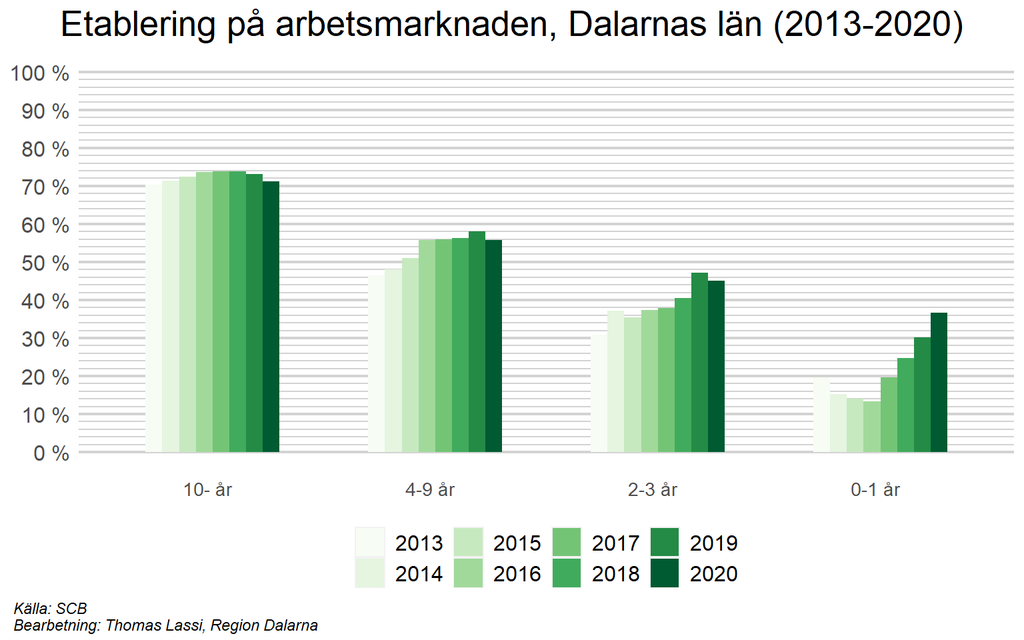

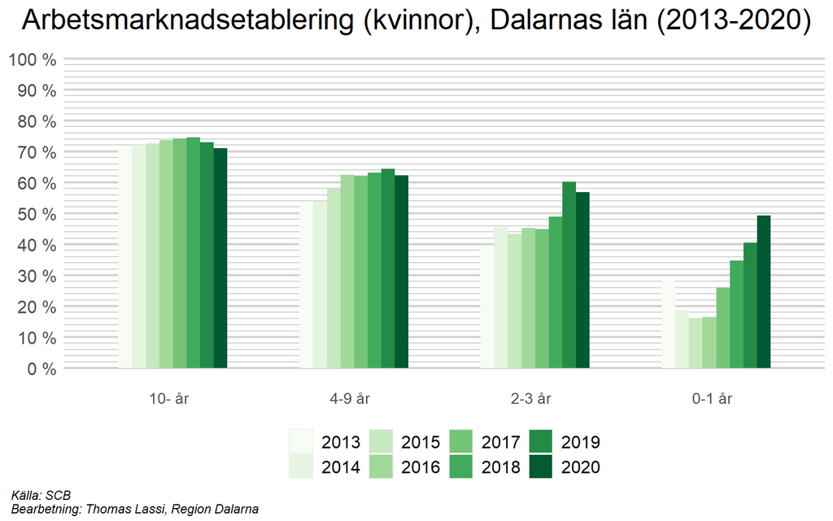

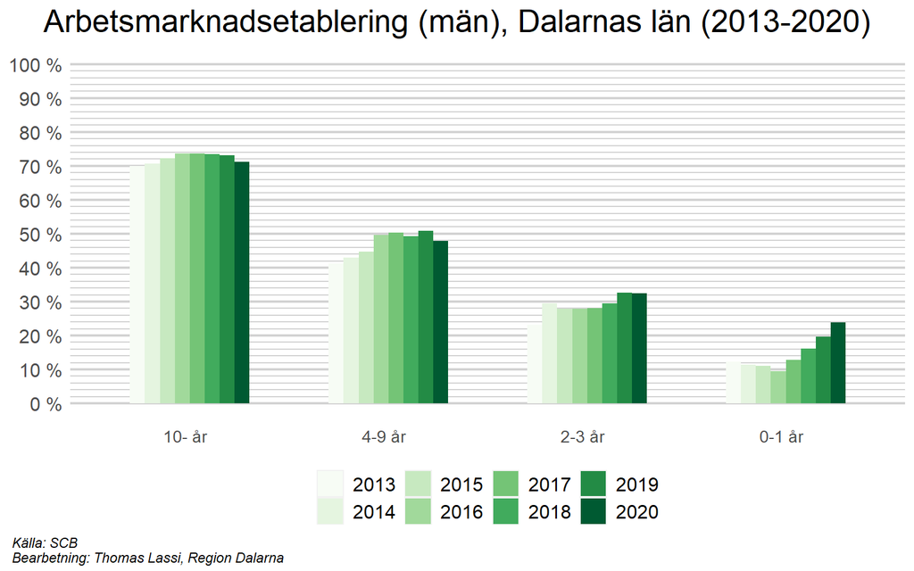

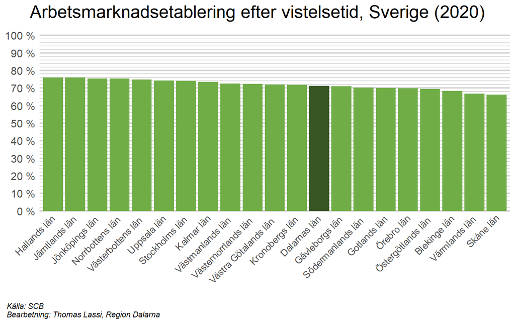

## Investeringar i FoU

För att lösa dagens och morgondagens samhällsutmaningar och för utveckling och konkurrenskraft krävs ökad innovationskraft. Individers, företags, organisationers och offentlig sektors innovationsförmåga påverkar platsers utvecklingskraft och möjligheter till omställning. Denna indikator mäter investeringar i forsking och utveckling i länet. Det bör dock noteras att innovation och forskning är ett synnerligen svårt område att mäta och att denna indikator främst ger en bild av hur stora resurser som investeras i länet.

Under tidsperioden från 2011 till 2019 ser vi en ökning i utgifter mätt i kronor per invånare i länet, från drygt 4900 kronor till drygt 5200 kronor per invånare. Investeringar sker främst bland företag med mindre bidrag från den offentliga sektorn samt universitet- och högskolesektorn. I ett nationellt perspektiv ser vi att Dalarna hamnar på den nedre halvan. Östergötland, som har den högsta noteringen för utgifter inom forskning och utveckling, har knappt sex gånger högre utgifter per invånare jämfört med Dalarna.

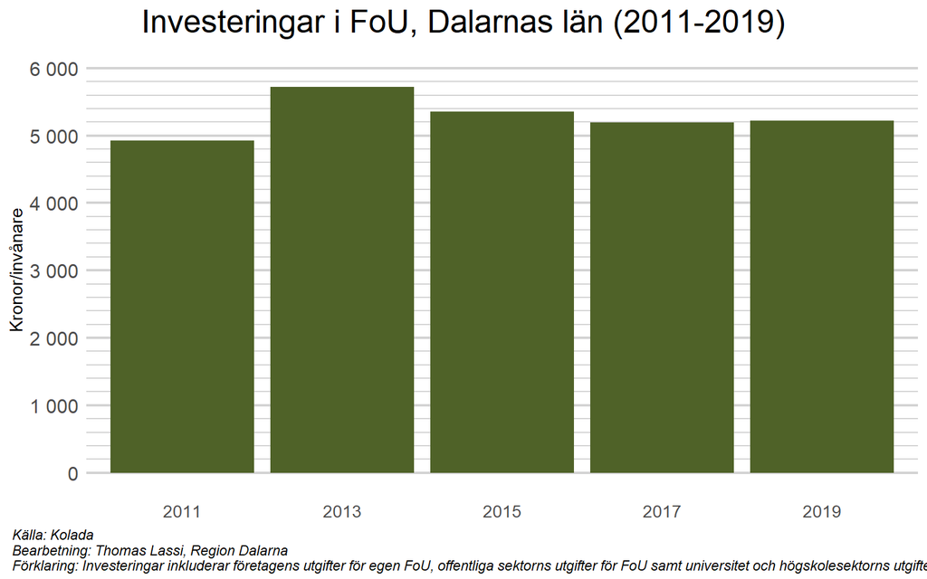

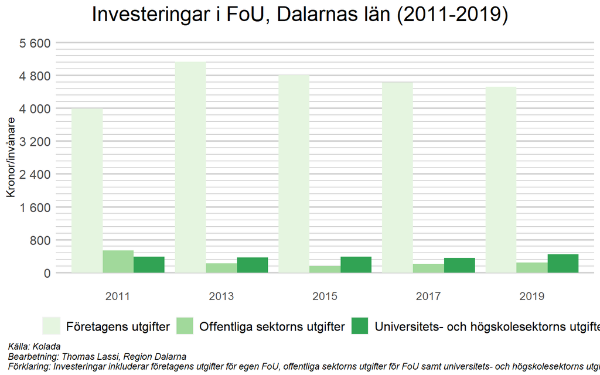

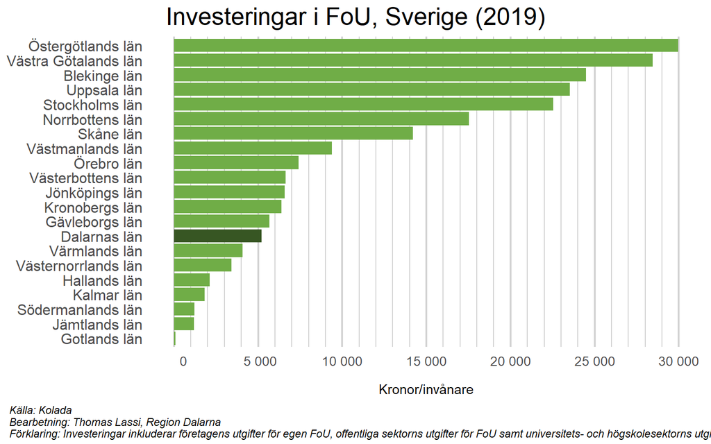